# Introduction to Git and GitHub

Heather Wheeler

2023-02-10 14:01:02

Portions adapted from https://happygitwithr.com/ and http://www.cureffi.org/2014/08/27/git-tutorial/

## Why Git?

Git is a version control system. It’s original purpose was to help groups of developers work collaboratively on big software projects. Git manages the evolution of a set of files – called a repository – in a sane, highly structured way. Think of it as the “Track Changes” features from Microsoft Word but much, much better.

Full participation in the bioinformatics community these days practically requires familiarity with Git and GitHub. Most publications include a GitHub repo (or other online repo) of the code used in the project. You will use GitHub to host and share your code as you work on your **Python Pipeline Project** and **Group Project**. There are also several **Repo Checks** throughout the semester to encourage continuous engagement with Git and GitHub. Git is already installed on the class servers. Below are directions on how to set up your GitHub account on `compbio.cs.luc.edu`, followed by a tutorial on how to use Git.

### 1. Make a GitHub account

Go to [GitHub.com](https://github.com/) and register yourself an account if you don’t already have one. If you use your `.edu` email address, you can sign up for [GitHub Global Campus](https://education.github.com/students), which gives you free private repos, but public repos are fine for this class.

#### OPTIONAL on your own: Install Git on your laptop (not necessary for the class)

For this class, interacting with GitHub from your browser and the server command line is adequate. If you’re planning to work exclusively from the class servers, you don’t need to install Git. If you’d like to use it locally from your laptop, follow these [directions](https://happygitwithr.com/install-git.html).

### 2. Introduce yourself to Git

*You only have to set this up once per machine. We’ll do the first this on `compbio.cs.luc.edu` together and then you should do it on `compbio1.cs.luc.edu` and your laptop (if desired).*

From the command line, tell `git` your name and **GitHub email** by typing (use your own name and email in the single quotes):

`git config --global user.name 'Heather Wheeler'`

`git config --global user.email 'hwheeler1@luc.edu'`

- This **must** be the email that you used to sign up for GitHub.

The above commands return nothing. You can check that `git` understood what you typed by looking at the output of:

`git config --global --list`

Resources:

- [GitHub’s advice](https://help.github.com/articles/set-up-git)
- [Quick primer on the shell](https://happygitwithr.com/shell.html)

### 3. Make your first repo on GitHub

Go to https://github.com and make sure you are logged in.

Click green “New” repository button. Or, if you are on your own profile page, click on “Repositories”, then click the green “New” button.

Repository name: `myrepo` (or whatever you wish)  
Choose “Public” and check the box next to “Add a README file.”

Click big green button “Create repository.”

Click big green button “Code” and copy the HTTPS clone URL. There is clipboard icon near the right side under the description.

### 4. Clone the repo to your directory on the class server

Go back to the [shell](https://happygitwithr.com/shell.html) on `compbio.cs.luc.edu`.

Take note of what directory you’re in. Use `pwd` to display working directory and `cd` to move around.

Clone `myrepo` from GitHub to your computer. This URL should have **your GitHub username** and the name of **your practice repo**. If your [shell](https://happygitwithr.com/shell.html) cooperates, you should be able to paste the whole `https://....` bit that we copied above. But some shells are not (immediately) clipboard aware. Type it. **Accurately.**

```bash
git clone https://github.com/<YOUR-USERNAME>/<YOUR-REPOSITORY>.git
```

This should look something like this:

```bash
hwheeler@compbio:~$ git clone https://github.com/hwheeler01/myrepo.git
Cloning into 'myrepo'...
remote: Enumerating objects: 3, done.
remote: Counting objects: 100% (3/3), done.
remote: Total 3 (delta 0), reused 0 (delta 0), pack-reused 0
Unpacking objects: 100% (3/3), done.
```

Make this new repo your working directory, list its files, display the README, and get some information on its connection to GitHub:

```bash
cd myrepo
ls
cat README.md
git remote show origin
```

This should look something like this:

```bash
hwheeler@compbio:~$ cd myrepo/
hwheeler@compbio:~/myrepo$ ls
README.md
hwheeler@compbio:~/myrepo$ cat README.md
# myrepo
hwheeler@compbio:~/myrepo$ git remote show origin
* remote origin
  Fetch URL: https://github.com/hwheeler01/myrepo.git
  Push  URL: https://github.com/hwheeler01/myrepo.git
  HEAD branch: master
  Remote branch:
    master tracked
  Local branch configured for 'git pull':
    master merges with remote master
  Local ref configured for 'git push':
    master pushes to master (up to date)
```

### How does git work?

Here is a diagram of the different zones of your git universe and how different actions affect them.

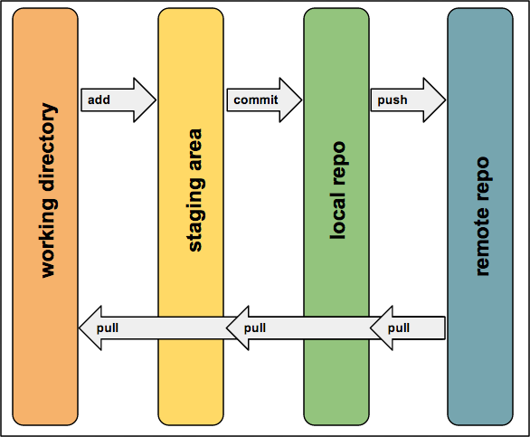

If your needs are relatively simple, then in a typical usage you would:

- Create local files however you like - maybe in the text editor nano
- `git add` your changes to be tracked by git
- `git commit` your changes to your local git repo
- `git push` your changes from local to your remote repo (GitHub.com)
- `git pull` any remote changes to your local repo

### 5. Set up a PAT (personal access token) so you can push to GitHub

Go to https://github.com/settings/tokens and click “Generate token”, followed by “Generate new token (classic)”.

Name your token, select 90 days expiration, and select scopes. Select all the options under “Select scopes”.

[figure not shown]

Once options are selected, click the green “Generate Token” button.

### KEY POINT: Make sure to copy your PAT now or keep your browser open until your credentials are cached in step 8. You won’t be able to see it again!

- Your PAT will look like this `ghp_xxxxxxxxxxxxxxxxxxxxxxxxxxxxxxxxxxxx` where the x’s are other characters.
- Treat this like a password, don’t share it with anyone and don’t hard code it into your scripts. If you lose it and need, you can easily generate a new PAT the same way.

### 6. Make a local change, then: add, commit, and push

Add a line to README and verify that Git notices the change:

```bash
echo " Some words I wrote on the compbio server" >> README.md
git status
```

This should look something like this:

```bash
hwheeler@compbio:~/myrepo$ echo " Some words I wrote on the compbio server" >> README.md
hwheeler@compbio:~/myrepo$ git status
On branch master
Your branch is up to date with 'origin/master'.

Changes not staged for commit:
  (use "git add <file>..." to update what will be committed)
  (use "git checkout -- <file>..." to discard changes in working directory)

    modified:   README.md

no changes added to commit (use "git add" and/or "git commit -a")
```

Commit this change and push to your remote repo on GitHub.

```bash
git add README.md
git commit -m "A commit from the compbio server"
git push
```

This should look something like this:

```bash
hwheeler@compbio:~/myrepo$ git add README.md
hwheeler@compbio:~/myrepo$ git commit -m "A commit from the compbio server"
[master bf105dd] A commit from the compbio server
 1 file changed, 1 insertion(+), 1 deletion(-)
hwheeler@compbio:~/myrepo$ git push
Username for 'https://github.com': hwheeler01
Password for 'https://hwheeler01@github.com':
Counting objects: 3, done.
Writing objects: 100% (3/3), 307 bytes | 307.00 KiB/s, done.
Total 3 (delta 0), reused 0 (delta 0)
To https://github.com/hwheeler01/myrepo.git
   2e0f314..bf105dd  master -> master
```

If this is the first time you’ve used your account on this particular machine, you will be challenged for your GitHub username and password. Your password is the PAT you just generated. Provide them!

### 7. Confirm the local change propagated to the GitHub remote

Go back to the browser.

Find the GitHub repo you started and refresh the page.

You should see the new " Some words I wrote on the compbio server" in the README.

If you click on “2 commits” (upper right) you should see one with the message “A commit from the compbio server.”

### 8. Am I really going to type my GitHub username and PAT on each push?

Needing to provide your username and PAT every time you push will drive you crazy in the long-run and make you reluctant to push. On Linux, you can cache your credentials with this command to store your PAT for **ten million seconds** or around 16 weeks:

`git config --global credential.helper 'cache --timeout=10000000'`

You will have to enter your username and password (PAT) one last time the next time you push, but then you’re set for the semester. Do this step on both `compbio.cs.luc.edu` and `compbio1.cs.luc.edu` so you can use git from either server.

### 9. Add, commit, push a script, then change it

Let’s say you’d like to add a solution to the nucleotide counting problem from BIOL 388/488 to your GitHub repo. Here’s what mine looks like:

```python
#!/usr/bin/python3
s = open('rosalind_dna.txt','r').read()
a = s.count("A")
c = s.count("C")
g = s.count("G")
t = s.count("T")
print(a, c, g, t)
```

Open a new file called DNA.py with your favorite text editor, e.g., nano. Copy and paste the code above into this file and save.

```bash
#copy the script into DNA.py and save
nano DNA.py
#add, commit, push to your repo
git add DNA.py
git commit -m 'add nt count script'
git push
```

Refresh GitHub to confirm your script was added.

Now, let’s say you’ve discovered a “more efficient” way to write your python script by using a for loop. Open your script with nano and edit to something like this:

```python
#!/usr/bin/python3
s = open('rosalind_dna.txt','r').read()
for n in ["A","C","G","T"]:
    print(s.count(n), end=' ')
```

Check for differences between your local working directory and your GitHub repo.

```bash
git diff
```

Your screen should look something like this:

```bash
hwheeler@compbio:~/myrepo$ git diff
diff --git a/DNA.py b/DNA.py
index 98645e6..31909f7 100644
--- a/DNA.py
+++ b/DNA.py
@@ -1,7 +1,4 @@
 #!/usr/bin/python3
 s = open('rosalind_dna.txt','r').read()
-a = s.count("A")
-c = s.count("C")
-g = s.count("G")
-t = s.count("T")
-print(a, c, g, t)
+for n in ["A","C","G","T"]:
+       print(s.count(n), end=' ')
```

Now add, commit (**with a relevant message!!!**), and push just like before.

```bash
git add DNA.py
git commit -m 'shortened DNA.py with a for loop'
git push
```

See how things have changed at GitHub.

### 10. Suggestions for using GitHub in a group

- Designate one member to maintain the primary repository
- All other members *fork* the primary repository and *clone* it to their local machine/home directory
- Any changes made by other members can be submitted as pull requests to the primary repository owner
- Primary owner can decide whether to accept the changes or not
- This way, multiple copies of your code will be floating around in case one member does something stupid and deletes their entire repository

Ok, but how do we fork and clone repositories? We’ll do an example next, but see https://help.github.com/articles/fork-a-repo/ for more explanation.

Let’s practice by forking Dr. Wheeler’s repository called `DrW_myrepo`

First, go to https://github.com/hwheeler01/DrW_myrepo while you are logged in to GitHub and click **Fork** near the upper right, followed by “**Create fork**”.

From your shell:

```bash
#move up one directory from your myrepo
cd ..
#clone YOUR GitHub repo to your local machine/home directory
#after forking, click the green "Code" button and clipboard to copy address
git clone https://github.com/<YOUR-USERNAME>/DrW_myrepo.git
cd DrW_myrepo
#specify Dr. Wheeler's repo is upstream of your copy
git remote add upstream https://github.com/hwheeler01/DrW_myrepo.git
git remote -v
```

The final command above should look like:

```bash
hwheeler@compbio:~/DrW_myrepo$ git remote -v
origin  https://github.com/<YOUR-USERNAME>/DrW_myrepo.git (fetch)
origin  https://github.com/<YOUR-USERNAME>/DrW_myrepo.git (push)
upstream  https://github.com/hwheeler01/DrW_myrepo.git (fetch)
upstream  https://github.com/hwheeler01/DrW_myrepo.git (push)
```

### KEY POINT: Every time you start a coding session in your local forked repository, sync with the upstream branch to get any updates.

To sync your fork with the upstream DrW_repo:

```bash
#make sure you are in your DrW_myrepo directory
git fetch upstream
git checkout master
git merge upstream/master
```

See more details here: https://help.github.com/articles/syncing-a-fork/

### Sending a pull request.

How does a group member submit a pull request (change) to the primary group member? Let’s say you’ve come up with any even shorter `DNA.py` script and changed the file in your local working directory to this:

```python
#!/usr/bin/python3
s = open('rosalind_dna.txt','r').read()
print(s.count("A"), s.count("C"), s.count("G"), s.count("T"))
```

Add, commit, and push the change to your forked repo.

```bash
git add DNA.py
git commit -m '2 liner'
git push
```

Compare files at GitHub. Go to your forked `DrW_myrepo` repository and notice the box that says “This branch is 1 commit ahead of hwheeler01:master.” Click the “Contribute” link on the right side of the box, followed by “Open pull request”. This will take you to a page similar to the screen shot below comparing the differences between the two forks:

- **base repository** `hwheeler01/DrW_myrepo`
- **head repository** `YOUR-USERNAME/DrW_myrepo`

Add a brief message about what you changed in the comments.

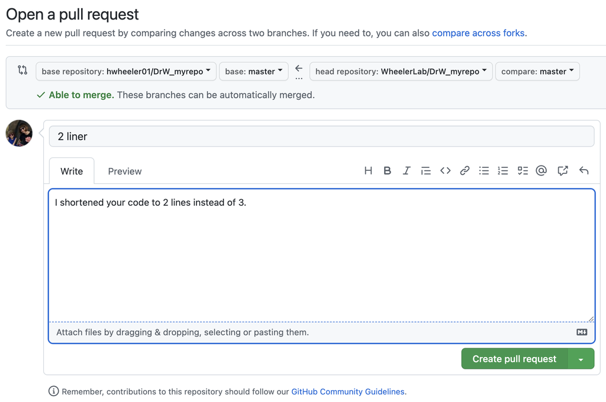

Then, you guessed it, click the green “Create pull request button” one more time and a pull request will be sent to Dr. Wheeler (or, when working in your groups, your primary repository owner).

Now she will decide if she likes your change and click “Merge pull request” if she does or “Close pull request” if she doesn’t:

[figure not shown]

For more details on creating and merging pull requests:

https://help.github.com/articles/creating-a-pull-request/

https://help.github.com/articles/merging-a-pull-request/

### 11. Other useful information

- Try to organize your work so multiple group members aren’t working on the same file (or the same portion of the file) at the same time, but here’s what to do if you have a [merge conflict](http://kbroman.org/github_tutorial/pages/merge_conflicts.html).
- Once you get the hang of git add/commit/push, you may want to try [branches](https://happygitwithr.com/git-branches.html). Branching means that you take a detour from the main stream of development (master branch) and do work without changing the main stream. Git encourages workflows that create small branches for exploration or new features, often merging them back together quickly. See [here](https://git-scm.com/book/en/v2/Git-Branching-Basic-Branching-and-Merging) for the basics of branching and merging.
- Don’t push large files to GitHub (>50 MB). If your project requires large input files, talk to Dr. Wheeler about options for storing them. See [GitHub’s policy](https://help.github.com/articles/what-is-my-disk-quota/) for more info.
- In addition to storing and tracking all your code, use GitHub to store key journal articles, your presentation slides or links, and test input files.
- Most of all, don’t get discouraged if things go wrong. The Git learning curve is steep. https://xkcd.com/1597/

### KEY TIPS:

- **Add and commit new scripts and other small files throughout your coding session.**
- **Always push everything at the end of a session so your GitHub repository is updated with your new work.**
- **If you make an edit on the GitHub website itself, be sure to do a `git pull` before you resume working on your local files.**
- **At the beginning of a coding session, always do a `git pull` to make sure your local files are up to date. If your repo is a forked copy, also sync with the upstream repo before making changes.**